# Introduction to Bioconductor exercises

Tom Carroll

## Working with BSgenome objects using Biostrings

In these exercises will gain some experience working with the BSgenome packages.

1. Load the library BSgenome.Hsapiens.UCSC.hg19

```r
library(BSgenome.Hsapiens.UCSC.hg19)
```

2. Count the number of contigs.

```r
length(seqnames(BSgenome.Hsapiens.UCSC.hg19))
```

```
## [1] 93
```

3. Give the sum of lengths of the 3 smallest chromosomes.

```r
contigLengths <- seqlengths(BSgenome.Hsapiens.UCSC.hg19)
sum(contigLengths[order(contigLengths,decreasing = FALSE)][1:3])
```

```
## [1] 35841
```

4. How many unknown bases - base *N* - are in chromosome 20

```r
alpFreq <-alphabetFrequency(BSgenome.Hsapiens.UCSC.hg19$chr20)
alpFreq["N"]
```

```
##       N
## 3520000
```

5. Create a barchart of the total number of the A,T,C,G bases on chromosome 20.

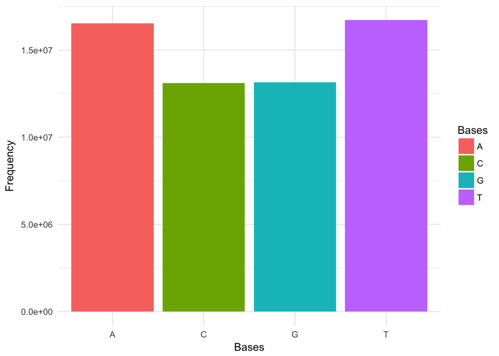

```r
library(ggplot2)
alpFreq <-alphabetFrequency(BSgenome.Hsapiens.UCSC.hg19$chr20)
atcgFreq <- alpFreq[c("A","T","C","G")]
atcgFreqDF <- data.frame(Bases=names(atcgFreq),Frequency=atcgFreq)
ggplot(atcgFreqDF,aes(y=Frequency,x=Bases,fill=Bases))+geom_bar(stat = "identity")+theme_minimal()
```

6. Extract the sequence from chromosome 20 at position 1,000,000 to 1,000,020 and retrieve the complement sequence

```r
mySeq <- BSgenome.Hsapiens.UCSC.hg19$chr20[1000000:1000020]
complement(mySeq)
```

```
##   21-letter "DNAString" instance
## seq: CACCCTCTCTTGACCTTGTTC
```

7. Write this complement sequence to a FASTA file.

```r
mySet <- DNAStringSet(complement(mySeq))
names(mySet) <- "testFasta"
writeXStringSet(mySet,filepath ="Data/testFasta.fa")
```

8. Look up the position of MYC in IGV (Human hg19) and find the genomic coordinates of its first exon.

```r
chr8:128748315-128748869
```

9. Extract the sequence for the first exon.

```r
mySeq <- BSgenome.Hsapiens.UCSC.hg19$chr8[128748315:128748869]
```

10. Compare the sequence to that found in IGV and identify start of translated region in gene
11. Count the number of classical start codons (ATG) in the first exon.

```r
countPattern("ATG",mySeq)
```

```
## [1] 0
```

12. Use IGV to review translation start codon for Gapdh and similarly count occurrence of ATG in exon 2 of NM_001289745 transcript. (chr12:6643976-6644027)

```r
gapdhSeq <- BSgenome.Hsapiens.UCSC.hg19$chr12[6643976:6644027]
countPattern("ATG",gapdhSeq)
```

```
## [1] 1
```